# Exploring CSE Impact Tool data

Wider Solent region

Ben Anderson (b.anderson@soton.ac.uk, `@dataknut`)

Last run at: 2021-03-09 17:51:18

# 1 Introduction

Exploration of Hampshire area data downloaded from the CSE Impact Toolkit (https://impact-tool.org.uk/about). Note that there is no obvious data re-use license on the impact-tool website. However the data is free to download so…

The data is modelled:

- Territorial emissions
- Consumption emissions

For Parishes and Local Authorities.

The methodology under-pinning the model is [open and transparent](https://impact-tool.org.uk/methodology).

> Health warning: this is modelled data giving the ‘expected’ emissions for the area. Although some modeled estimates can be constrained to fit observed data (e.g. LSOA level total residential eletricity & gas consumption); much of it cannot. This means that specific local conditions will lead to the estimates being ‘wrong’ and in some cases these may be obviously so. This is more likely to be obvious at finer geographical (i.e. parish) levels, especially where ‘unusual’ patterns of infrastructure pertain.

> As a result these estimates are best viewed as the ‘expected’ emissions “all other things being equal”. If we could actually measure the emissions we might find ‘good’ places which are doing much better than ‘expected’ (or worse). It would then be interesting to find out why…

This brief report explores the data for the Hampshire area:

- Hampshire County
- Southampton
- Portsmouth
- Isle of Wight

# 2 Local Authority level

```r
f <- path.expand(paste0(rmdParams$csePath, "/local-authority-all-territorial-absolute.csv.gz"))
absTerrDT <- data.table::fread(f)
absTerrDT[, source := "Territorial absolute"]
atmDT <- melt(absTerrDT)

f <- path.expand(paste0(rmdParams$csePath, "/local-authority-all-consumption-absolute.csv.gz"))
absConsDT <- data.table::fread(f)
absConsDT[, source := "Consumption absolute"]
actmDT <- melt(absConsDT)

laAbsDT <- rbind(atmDT, actmDT)

# Local Council
# Isle of Wight
# Southampton
# Portsmouth
# Basingstoke & Deane
# East Hampshire
# Eastleigh
# Fareham
# Gosport
# Hart
# Havant
# New Forest
# Rushmoor
# Test Valley
# Winchester

solent_laAbsDT <- laAbsDT[name %like% "Hampshire" |
                            name %like% "Basingstoke" |
                            name %like% "Eastleigh" |
                            name %like% "Fareham" |
                            name %like% "Gosport" |
                            name == "Hart" |
                            name == "Havant" |
                            name %like% "New Forest" |
                            name == "Rushmoor" |
                            name %like% "Test Valley" |
                            name %like% "Winchester" |
                            name %like% "Southampton" |
                            name %like% "Portsmouth" |
                            name %like% "Isle of Wight" |
                            name %like% "Southampton"]

f <- path.expand(paste0(rmdParams$csePath, "/local-authority-all-territorial-per-household.csv.gz"))
phTerrDT <- data.table::fread(f)
phTerrDT[, source := "Territorial per household"]
phtmDT <- melt(phTerrDT)

f <- path.expand(paste0(rmdParams$csePath, "/local-authority-all-consumption-per-household.csv.gz"))
phConsDT <- data.table::fread(f)
phConsDT[, source := "Consumption per household"]
phctmDT <- melt(phConsDT)

laPhDT <- rbind(phtmDT, phctmDT)

solent_laPhDT <- laPhDT[name %like% "Hampshire" |
                            name %like% "Basingstoke" |
                            name == "Hart" |
                            name %like% "Eastleigh" |
                            name %like% "New Forest" |
                            name %like% "Test Valley" |
                            name %like% "Portsmouth" |
                            name %like% "Isle of Wight" |
                            name %like% "Southampton"]

t <- solent_laAbsDT[, .(nVariables = .N), keyby = .(name)]

ft <- flextable(t)

set_caption(ft, caption = "Local Authorities included")
```

Table 2.1: Local Authorities included

| name | nVariables |
| --- | --- |
| Basingstoke and Deane | 36 |
| East Hampshire | 36 |
| Eastleigh | 36 |
| Fareham | 36 |
| Gosport | 36 |
| Hart | 36 |
| Havant | 36 |
| Isle of Wight | 36 |
| New Forest | 36 |
| Portsmouth | 36 |
| Rushmoor | 36 |
| Southampton | 36 |
| Test Valley | 36 |
| Winchester | 36 |

Any missing?

## 2.1 Territorial emissions

Figure 2.1 shows the absolute values for territorial emissions. The plot is visually dominated by ‘power generation’ in the New Forest.

```r
dt <- solent_laAbsDT[source == "Territorial absolute",
                     .(tCO2e = mean(value)),
                     keyby = .(variable, name)]

t <- dcast(dt,  variable ~  name)
ft <- flextable::flextable(t)
ft <- set_caption(ft,
            caption = "Territorial emissions: absolute T CO2e")
ft <- colformat_num(ft, 2:10, digits = 2)
flextable::autofit(ft)
```

Table 2.2: Territorial emissions: absolute T CO2e

| variable | Basingstoke and Deane | East Hampshire | Eastleigh | Fareham | Gosport | Hart | Havant | Isle of Wight | New Forest | Portsmouth | Rushmoor | Southampton | Test Valley | Winchester |
| --- | --- | --- | --- | --- | --- | --- | --- | --- | --- | --- | --- | --- | --- | --- |
| Housing - Mains gas (t CO2e) | 147,023.80 | 117,246.69 | 117,495.14 | 105,583.15 | 61,982.08 | 105,821.21 | 112,952.56 | 119,302.02 | 169,568.25 | 155539.9380 | 84419.4500 | 164399.3360 | 91074.957 | 105049.9160 |
| Housing - Electricity (t CO2e) | 78,059.00 | 59,941.29 | 51,081.78 | 46,645.44 | 33,380.57 | 43,065.63 | 51,269.58 | 67,417.29 | 82,569.40 | 76323.2150 | 35761.9350 | 98010.1210 | 60124.250 | 57665.2490 |
| Housing - Oil (t CO2e) | 56,696.59 | 39,414.71 | 1,776.53 | 2,433.82 | 76.44 | 9,516.95 | 704.05 | 18,384.06 | 40,393.22 | 17.4950 | 61.1450 | 102.5000 | 73274.436 | 51180.0210 |
| Housing - LPG (t CO2e) | 3,591.26 | 5,081.61 | 1,106.17 | 918.83 | 175.20 | 1,776.58 | 697.82 | 4,783.99 | 5,782.02 | 472.5850 | 226.9520 | 349.2860 | 6643.444 | 6365.5550 |
| Housing - Biomass (t CO2e) | 848.64 | 1,047.42 | 302.08 | 307.19 | 69.87 | 478.90 | 253.71 | 744.80 | 1,419.59 | 152.9540 | 147.3880 | 243.3950 | 876.773 | 1112.8430 |
| Housing - Coal (t CO2e) | 1,179.32 | 1,122.30 | 313.84 | 409.54 | 259.27 | 278.47 | 514.10 | 1,058.53 | 2,003.98 | 531.2630 | 332.4920 | 794.9130 | 1146.400 | 1085.9000 |
| Industrial and commercial - Electricity (t CO2e) | 119,331.98 | 48,625.99 | 76,113.93 | 57,726.91 | 33,819.21 | 63,174.50 | 47,968.54 | 65,308.33 | 102,653.75 | 143882.5330 | 58329.6941 | 128052.3538 | 76714.128 | 88283.7207 |
| Industrial and commercial - Mains gas (t CO2e) | 80,817.89 | 24,563.25 | 31,501.54 | 49,596.39 | 17,550.20 | 26,108.21 | 19,749.00 | 82,866.21 | 45,729.95 | 78973.9296 | 39336.4675 | 97616.2671 | 61728.728 | 46393.9226 |
| Industrial and commercial - Other Fuels (t CO2e) | 40,751.48 | 46,692.26 | 23,806.63 | 15,936.83 | 7,686.69 | 21,163.15 | 20,065.98 | 32,396.15 | 62,564.65 | 37391.4692 | 14690.5685 | 31532.0174 | 50945.509 | 37812.6888 |
| Industrial and commercial - Large industrial consumers (t CO2e) | 553.51 | 0.00 | 0.00 | 3,537.65 | 126.87 | 81.32 | 1,896.31 | 1,468.57 | 70,203.44 | 2103.2965 | 0.0000 | 349.0314 | 1142.551 | 0.0000 |
| Power generation (t CO2e) | 6,086.44 | 1,426.74 | 1.48 | 1,736.98 | 0.23 | 368.38 | 1,709.73 | 4,079.53 | 1,734,141.06 | 6551.7534 | 13778.4803 | 400428.3295 | 1453.678 | 748.7915 |
| Agriculture - Fuel (t CO2e) | 16,773.77 | 13,180.75 | 1,693.42 | 1,603.40 | 304.60 | 4,493.53 | 933.17 | 11,325.71 | 14,651.75 | 509.0324 | 291.1050 | 423.4139 | 20220.507 | 20344.4235 |
| Agriculture - Livestock and crop-related emissions (t CO2e) | 60,498.69 | 52,425.93 | 5,393.35 | 3,843.98 | 1,434.72 | 15,119.49 | 2,038.80 | 92,296.64 | 64,998.18 | 1441.3468 | 264.4438 | 353.0500 | 70706.621 | 86220.2738 |
| Aviation (t CO2e) | 106,423.41 | 73,085.74 | 79,831.03 | 70,456.17 | 51,648.32 | 58,316.10 | 76,193.73 | 85,716.96 | 108,860.39 | 130286.9021 | 57619.0377 | 153096.0276 | 75803.718 | 75274.4140 |
| Shipping (t CO2e) | 42,387.47 | 29,109.38 | 31,795.97 | 28,062.05 | 20,571.05 | 23,226.77 | 30,347.27 | 34,140.29 | 43,358.10 | 51892.0857 | 22949.1376 | 60976.7525 | 30191.930 | 29981.1130 |
| Diesel fuelled railways (t CO2e) | 13,873.00 | 509.72 | 9,247.69 | 883.37 | 0.00 | 1,729.88 | 120.36 | 0.00 | 3,059.11 | 1986.6946 | 1459.7709 | 742.1455 | 9856.606 | 1881.1531 |
| F-gases (t CO2e) | 40,218.79 | 16,388.56 | 25,652.89 | 19,455.86 | 11,398.18 | 21,291.88 | 16,166.97 | 22,011.05 | 34,597.68 | 48493.1374 | 19659.0219 | 43157.8473 | 25855.180 | 29754.5123 |
| Road Transport (t CO2e) | 534,643.62 | 342,258.55 | 277,475.81 | 216,288.69 | 63,699.65 | 235,161.67 | 171,377.80 | 120,395.01 | 479,560.55 | 291295.4311 | 137326.5835 | 233518.2229 | 469127.543 | 482441.6985 |
| Other Transport (t CO2e) | 2,591.27 | 2,694.53 | 7,638.19 | 1,088.53 | 331.37 | 1,378.14 | 917.36 | 726.13 | 2,495.40 | 1414.3609 | 776.2174 | 4424.7332 | 2137.957 | 2616.7733 |
| Waste management (t CO2e) | 83,856.70 | 44,936.93 | 13,969.24 | 20,941.69 | 2,803.84 | 26,671.42 | 7,061.60 | 70,268.61 | 187,091.53 | 97437.0779 | 6051.8316 | 27411.1872 | 85509.424 | 29717.7077 |
| Land use, land-use change, and forestry (t CO2e) | -61,675.28 | -51,060.49 | -5,740.53 | -5,665.84 | -1,839.16 | -25,929.23 | -3,992.87 | -30,546.22 | -117,206.95 | -2293.1372 | -7577.8106 | -6015.5179 | -56599.544 | -49083.6279 |

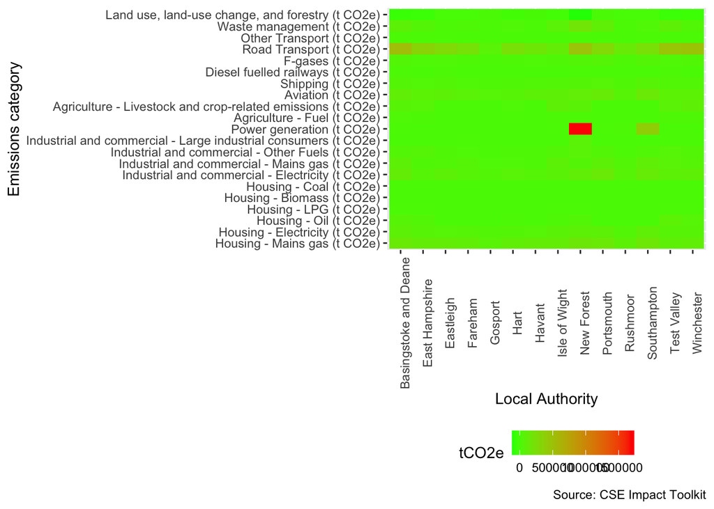

Figure 2.1: Wider Hampshire area total territorial emissions (T CO2e 2019-20)

```r
ggplot2::ggplot(dt, aes(x = name, y = variable, fill = tCO2e)) +
  geom_tile() +
  scale_fill_continuous(low = "green", high = "red") +
  theme(axis.text.x = element_text(angle = 90)) +
  theme(legend.position="bottom") +
  labs(caption = rmdParams$dataSource,
         x = "Local Authority",
         y = "Emissions category")
```

## 2.2 Consumption emissions

Consumption emissions are most likely to be driven by differences in socio-economic context and numbers of households within a local authority.

Figure 2.2 shows the absolute values while figure 2.3 shows per household values.

```r
dt <- solent_laAbsDT[source == "Consumption absolute",
                     .(tCO2e = mean(value)),
                     keyby = .(variable, name)]

t <- dcast(dt,  variable ~  name)
ft <- flextable::flextable(t)
ft <- set_caption(ft,
            caption = "Consumption emissions: absolute T CO2e")
ft <- colformat_num(ft, 2:10, digits = 2)
flextable::autofit(ft)
```

Table 2.3: Consumption emissions: absolute T CO2e

| variable | Basingstoke and Deane | East Hampshire | Eastleigh | Fareham | Gosport | Hart | Havant | Isle of Wight | New Forest | Portsmouth | Rushmoor | Southampton | Test Valley | Winchester |
| --- | --- | --- | --- | --- | --- | --- | --- | --- | --- | --- | --- | --- | --- | --- |
| Housing - Mains gas (t CO2e) | 147,023.80 | 117,246.69 | 117,495.14 | 105,583.15 | 61,982.08 | 105,821.21 | 112,952.56 | 119,302.02 | 169,568.25 | 155539.938 | 84419.450 | 164399.336 | 91074.957 | 105049.916 |
| Housing - Electricity (t CO2e) | 78,059.00 | 59,941.29 | 51,081.78 | 46,645.44 | 33,380.57 | 43,065.63 | 51,269.58 | 67,417.29 | 82,569.40 | 76323.215 | 35761.935 | 98010.121 | 60124.250 | 57665.249 |
| Housing - Oil (t CO2e) | 56,696.59 | 39,414.71 | 1,776.53 | 2,433.82 | 76.44 | 9,516.95 | 704.05 | 18,384.06 | 40,393.22 | 17.495 | 61.145 | 102.500 | 73274.436 | 51180.021 |
| Housing - LPG (t CO2e) | 3,591.26 | 5,081.61 | 1,106.17 | 918.83 | 175.20 | 1,776.58 | 697.82 | 4,783.99 | 5,782.02 | 472.585 | 226.952 | 349.286 | 6643.444 | 6365.555 |
| Housing - Biomass (t CO2e) | 848.64 | 1,047.42 | 302.08 | 307.19 | 69.87 | 478.90 | 253.71 | 744.80 | 1,419.59 | 152.954 | 147.388 | 243.395 | 876.773 | 1112.843 |
| Housing - Coal (t CO2e) | 1,179.32 | 1,122.30 | 313.84 | 409.54 | 259.27 | 278.47 | 514.10 | 1,058.53 | 2,003.98 | 531.263 | 332.492 | 794.913 | 1146.400 | 1085.900 |
| Consumption of goods and services - Purchase of goods (t CO2e) | 249,350.07 | 188,326.16 | 181,326.08 | 162,899.47 | 97,039.92 | 154,756.47 | 151,830.73 | 181,236.46 | 257,279.44 | 229667.315 | 124249.039 | 269696.885 | 184028.387 | 191726.576 |
| Consumption of goods and services - Use of services (t CO2e) | 110,434.88 | 82,872.61 | 82,839.36 | 73,511.83 | 46,218.64 | 68,576.19 | 71,057.01 | 84,527.35 | 114,382.80 | 108708.192 | 57446.689 | 129434.285 | 80585.313 | 84128.660 |
| Consumption of goods and services - Other consumption related emissions (t CO2e) | 93,605.82 | 70,786.69 | 71,921.24 | 62,406.62 | 39,766.57 | 55,210.40 | 60,373.11 | 79,263.58 | 102,018.90 | 99150.544 | 47243.589 | 112449.240 | 67193.545 | 72751.843 |
| Food and diet - Meat and fish (t CO2e) | 159,118.58 | 113,845.35 | 116,788.50 | 103,375.66 | 69,666.46 | 91,210.36 | 105,606.04 | 128,237.36 | 163,084.59 | 165612.355 | 83281.746 | 194248.368 | 114742.400 | 113203.537 |
| Food and diet - Other food and drink (t CO2e) | 133,991.58 | 99,027.06 | 96,869.95 | 86,097.03 | 53,874.23 | 81,037.38 | 83,172.54 | 99,024.43 | 135,907.32 | 128713.531 | 68200.721 | 150160.752 | 97496.081 | 100080.657 |
| Travel - Flights (t CO2e) | 95,652.30 | 83,698.26 | 62,908.89 | 58,092.47 | 28,768.08 | 68,920.66 | 50,350.72 | 66,245.48 | 102,737.79 | 68645.586 | 42108.317 | 74771.654 | 77584.689 | 89310.739 |
| Travel - Public transport (t CO2e) | 37,843.81 | 27,154.95 | 25,543.66 | 21,526.11 | 15,460.93 | 20,999.78 | 22,915.82 | 31,072.10 | 37,860.87 | 37642.193 | 18023.989 | 45897.271 | 27672.811 | 29546.984 |
| Travel - Private transport (t CO2e) | 138,387.53 | 102,371.73 | 89,485.90 | 73,448.74 | 48,745.25 | 79,199.85 | 71,825.77 | 105,165.10 | 134,373.99 | 118462.281 | 61475.681 | 140611.780 | 101444.647 | 113175.199 |
| Waste - Waste (t CO2e) | 3,587.91 | 2,437.44 | 2,582.18 | 2,238.30 | 1,650.32 | 1,920.66 | 2,478.57 | 13,361.90 | 3,499.02 | 2808.465 | 1961.597 | 5027.028 | 2523.449 | 2360.321 |

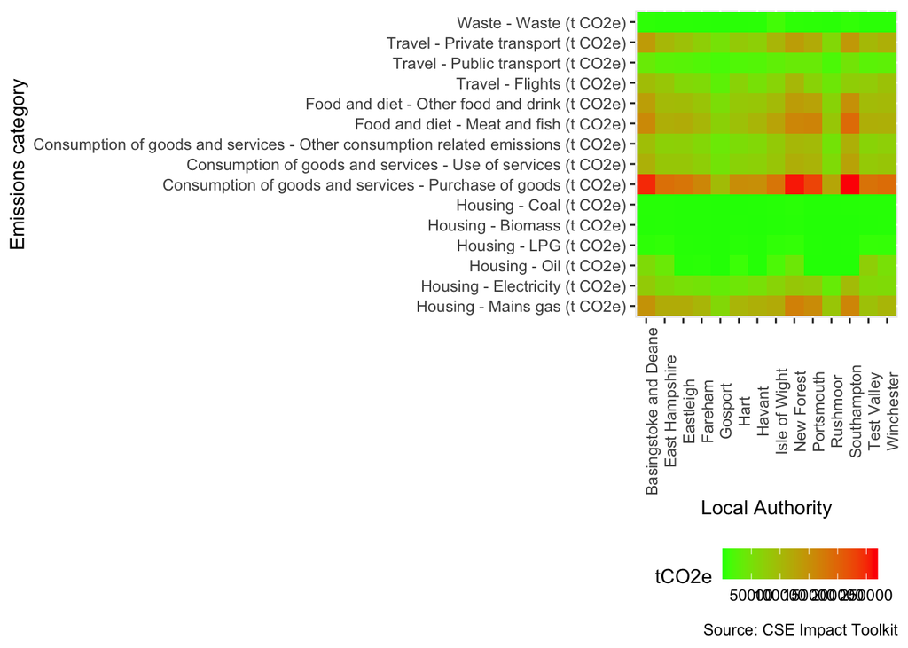

Figure 2.2: Wider Hampshire area total consumption emissions (T CO2e 2019-20)

```r
ggplot2::ggplot(dt, aes(x = name, y = variable, fill = tCO2e)) +
  geom_tile() +
  scale_fill_continuous(low = "green", high = "red") +
  theme(axis.text.x = element_text(angle = 90)) +
  theme(legend.position="bottom") +
  labs(caption = rmdParams$dataSource,
         x = "Local Authority",
         y = "Emissions category")
```

```r
dt <- solent_laPhDT[source %like% "Consumption",
                     .(tCO2e = mean(value)),
                     keyby = .(variable, name)]

t <- dcast(dt,  variable ~  name)
ft <- flextable::flextable(t)
ft <- set_caption(ft,
            caption = "Consumption emissions: per household T CO2e")
ft <- colformat_num(ft, 2:10, digits = 2)
flextable::autofit(ft)
```

Table 2.4: Consumption emissions: per household T CO2e

| variable | Basingstoke and Deane | East Hampshire | Eastleigh | Hart | Isle of Wight | New Forest | Portsmouth | Southampton | Test Valley |
| --- | --- | --- | --- | --- | --- | --- | --- | --- | --- |
| Housing - Mains gas (t CO2e) | 1.94 | 2.22 | 2.09 | 2.65 | 1.69 | 2.08 | 1.76 | 1.54 | 1.66 |
| Housing - Electricity (t CO2e) | 1.03 | 1.14 | 0.91 | 1.08 | 0.95 | 1.01 | 0.86 | 0.92 | 1.10 |
| Housing - Oil (t CO2e) | 0.75 | 0.75 | 0.03 | 0.24 | 0.26 | 0.49 | 0.00 | 0.00 | 1.34 |
| Housing - LPG (t CO2e) | 0.05 | 0.10 | 0.02 | 0.04 | 0.07 | 0.07 | 0.01 | 0.00 | 0.12 |
| Housing - Biomass (t CO2e) | 0.01 | 0.02 | 0.01 | 0.01 | 0.01 | 0.02 | 0.00 | 0.00 | 0.02 |
| Housing - Coal (t CO2e) | 0.02 | 0.02 | 0.01 | 0.01 | 0.01 | 0.03 | 0.01 | 0.01 | 0.02 |
| Consumption of goods and services - Purchase of goods (t CO2e) | 3.29 | 3.57 | 3.23 | 3.88 | 2.56 | 3.15 | 2.59 | 2.53 | 3.36 |
| Consumption of goods and services - Use of services (t CO2e) | 1.46 | 1.57 | 1.47 | 1.72 | 1.20 | 1.40 | 1.23 | 1.22 | 1.47 |
| Consumption of goods and services - Other consumption related emissions (t CO2e) | 1.23 | 1.34 | 1.28 | 1.38 | 1.12 | 1.25 | 1.12 | 1.06 | 1.23 |
| Food and diet - Meat and fish (t CO2e) | 2.10 | 2.16 | 2.08 | 2.29 | 1.81 | 2.00 | 1.87 | 1.82 | 2.10 |
| Food and diet - Other food and drink (t CO2e) | 1.77 | 1.88 | 1.72 | 2.03 | 1.40 | 1.66 | 1.45 | 1.41 | 1.78 |
| Travel - Flights (t CO2e) | 1.26 | 1.59 | 1.12 | 1.73 | 0.94 | 1.26 | 0.78 | 0.70 | 1.42 |
| Travel - Public transport (t CO2e) | 0.50 | 0.51 | 0.45 | 0.53 | 0.44 | 0.46 | 0.42 | 0.43 | 0.51 |
| Travel - Private transport (t CO2e) | 1.82 | 1.94 | 1.59 | 1.99 | 1.49 | 1.64 | 1.34 | 1.32 | 1.85 |
| Waste - Waste (t CO2e) | 0.05 | 0.05 | 0.05 | 0.05 | 0.19 | 0.04 | 0.03 | 0.05 | 0.05 |

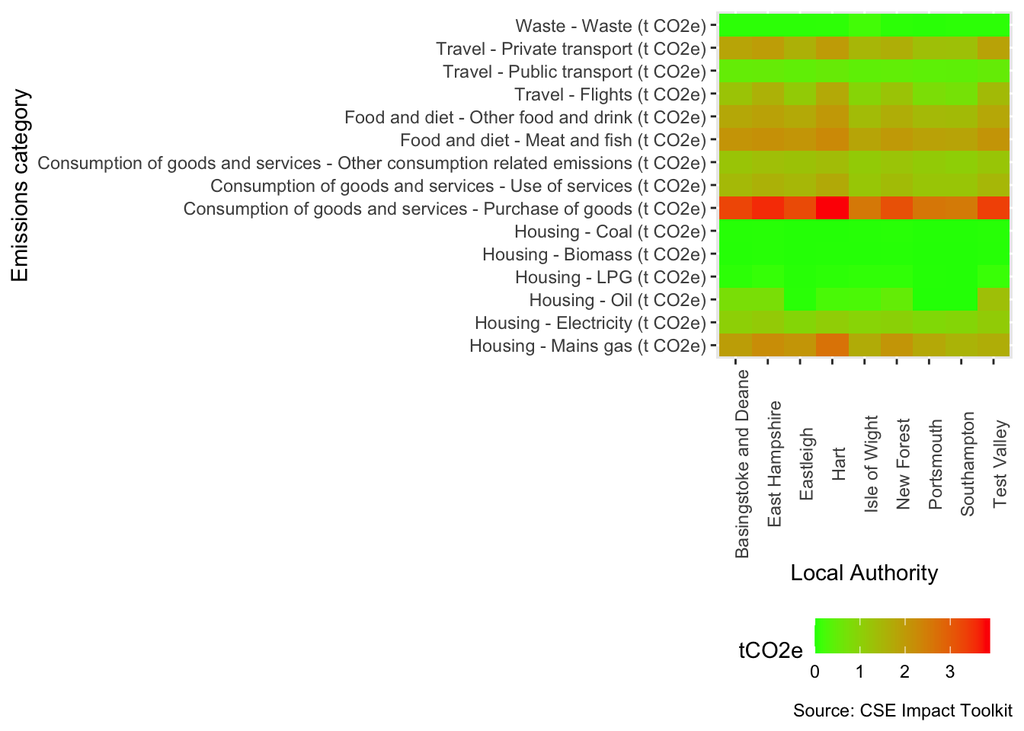

Figure 2.3: Wider Hampshire area per household consumption emissions (T CO2e 2019-20)

```r
ggplot2::ggplot(dt, aes(x = name, y = variable, fill = tCO2e)) +
  geom_tile() +
  scale_fill_continuous(low = "green", high = "red") +
  theme(axis.text.x = element_text(angle = 90)) +
  theme(legend.position="bottom") +
  labs(caption = rmdParams$dataSource,
         x = "Local Authority",
         y = "Emissions category")
```

# 3 Parish level

tbc

# 4 R Environment

Packages used:

- data.table (Dowle et al. 2015)
- ggplot2 (Wickham 2009)
- flextable (Gohel 2020)

# 5 Annexes

# References

Dowle, M, A Srinivasan, T Short, S Lianoglou with contributions from R Saporta, and E Antonyan. 2015. *Data.table: Extension of Data.frame*. https://CRAN.R-project.org/package=data.table.

Gohel, David. 2020. *Flextable: Functions for Tabular Reporting*. https://CRAN.R-project.org/package=flextable.

Wickham, Hadley. 2009. *Ggplot2: Elegant Graphics for Data Analysis*. Springer-Verlag New York. http://ggplot2.org.